# Clinical Response Integration

TCR Repertoire Analysis — Notebook 06

Joshua Luthy

2026-03-15

## Analysis Overview

```r
# Load all processed datasets
diversity   <- read_csv("../data/processed/diversity_metrics.csv")
auc_metrics <- read_csv("../data/processed/clonal_auc_metrics.csv")
top_clones  <- read_csv("../data/processed/top_clonotypes.csv")
patient_meta <- read_csv("../data/raw/patient_metadata.csv")
longitudinal <- read_csv("../data/processed/longitudinal_clonal_tracking.csv")
```

## Building the Feature Matrix

We aggregate all per-patient metrics into a single feature matrix for clinical correlation analysis.

```r
# Diversity features (Product only — characterizes the drug product)
product_diversity <- diversity %>%
  filter(sample_type == "Product") %>%
  select(patient_id, clinical_response,
         product_shannon    = shannon_entropy,
         product_clonality  = clonality,
         product_richness   = n_clonotypes,
         product_d50        = d50)

# Diversity fold change (Apheresis → Product)
diversity_fc <- diversity %>%
  select(patient_id, sample_type, shannon_entropy, n_clonotypes) %>%
  pivot_wider(names_from = sample_type, values_from = c(shannon_entropy, n_clonotypes)) %>%
  mutate(
    shannon_fc    = shannon_entropy_Product / shannon_entropy_Apheresis,
    richness_fc   = n_clonotypes_Product / n_clonotypes_Apheresis
  ) %>%
  select(patient_id, shannon_fc, richness_fc)

# AUC features (aggregated per patient)
auc_features <- auc_metrics %>%
  group_by(patient_id, clinical_response) %>%
  summarise(
    mean_auc          = mean(auc),
    max_auc           = max(auc),
    mean_persistence  = mean(persistence_ratio),
    mean_peak_freq    = mean(peak_frequency),
    n_persistent      = sum(persistence_ratio > 0.5),
    .groups = "drop"
  ) %>%
  select(-clinical_response)

# Top clone dominance
top1_features <- top_clones %>%
  filter(sample_type == "Product", rank == 1) %>%
  select(patient_id, top1_fraction = clone_fraction)

# Combine all features
feature_matrix <- product_diversity %>%
  left_join(diversity_fc, by = "patient_id") %>%
  left_join(auc_features, by = "patient_id") %>%
  left_join(top1_features, by = "patient_id") %>%
  left_join(patient_meta %>% select(patient_id, age, sex, prior_lines), by = "patient_id")

feature_matrix %>%
  mutate(across(where(is.numeric), ~round(., 4))) %>%
  knitr::kable(caption = "Integrated feature matrix — one row per patient")
```

Integrated feature matrix — one row per patient

| patient_id | clinical_response | product_shannon | product_clonality | product_richness | product_d50 | shannon_fc | richness_fc | mean_auc | max_auc | mean_persistence | mean_peak_freq | n_persistent | top1_fraction | age | sex | prior_lines |
| --- | --- | --- | --- | --- | --- | --- | --- | --- | --- | --- | --- | --- | --- | --- | --- | --- |
| PT-001 | CR | 4.4388 | 0.4171 | 2029 | 3 | 0.5549 | 0.1533 | 2.5144 | 39.5899 | 0.8557 | 0.3181 | 20 | 0.4246 | 60 | F | 2 |
| PT-002 | CR | 3.0637 | 0.5525 | 940 | 1 | 0.3779 | 0.0665 | 1.4826 | 21.4535 | 0.7888 | 0.1878 | 19 | 0.5482 | 46 | M | 2 |
| PT-003 | PR | 3.4408 | 0.5101 | 1123 | 2 | 0.4424 | 0.0963 | 0.7044 | 9.4410 | 0.3095 | 0.0983 | 1 | 0.4561 | 43 | M | 3 |
| PT-004 | PR | 4.8667 | 0.3771 | 2474 | 5 | 0.6146 | 0.1935 | 0.7002 | 9.6012 | 0.3025 | 0.1241 | 2 | 0.3454 | 59 | M | 4 |
| PT-005 | PD | 4.6019 | 0.3910 | 1913 | 5 | 0.6164 | 0.1958 | 0.2287 | 1.9401 | 0.0863 | 0.0445 | 0 | 0.2855 | 47 | F | 2 |
| PT-006 | PD | 5.2527 | 0.3398 | 2853 | 11 | 0.7212 | 0.3288 | 0.2544 | 2.8540 | 0.0966 | 0.0560 | 0 | 0.2488 | 58 | F | 2 |

## Correlation Heatmap

We examine pairwise correlations between all numeric features to identify the strongest predictors of clinical response grouping.

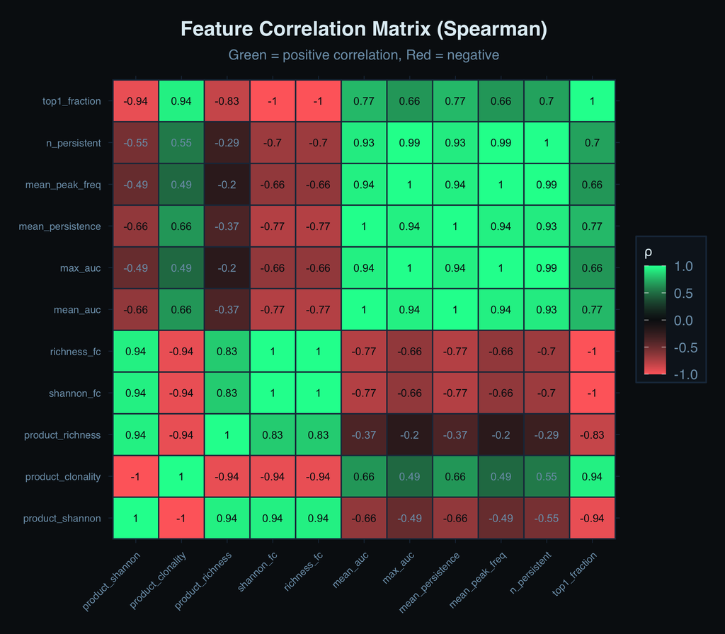

```r
# Compute correlation matrix
numeric_features <- feature_matrix %>%
  select(where(is.numeric), -age, -prior_lines) %>%
  select(-product_d50)  # Remove integer-only column for cleaner correlations

cor_mat <- cor(numeric_features, use = "pairwise.complete.obs", method = "spearman")

# Reshape for ggplot heatmap
cor_long <- as.data.frame(as.table(cor_mat)) %>%
  rename(feature1 = Var1, feature2 = Var2, correlation = Freq)

ggplot(cor_long, aes(x = feature1, y = feature2, fill = correlation)) +
  geom_tile(color = "#1e3348", linewidth = 0.5) +
  geom_text(aes(label = round(correlation, 2)),
            color = ifelse(abs(cor_long$correlation) > 0.6, "#0a0f14", "#7b9db5"),
            size = 3) +
  scale_fill_gradient2(
    low = "#ff6b6b", mid = "#0a0f14", high = "#00ff9d",
    midpoint = 0, limits = c(-1, 1)
  ) +
  labs(
    title = "Feature Correlation Matrix (Spearman)",
    subtitle = "Green = positive correlation, Red = negative",
    fill = "ρ"
  ) +
  theme(
    axis.text.x = element_text(angle = 45, hjust = 1, size = 8),
    axis.text.y = element_text(size = 8),
    axis.title   = element_blank()
  )
```

## Feature Distributions by Response

### Key Metrics Across Response Groups

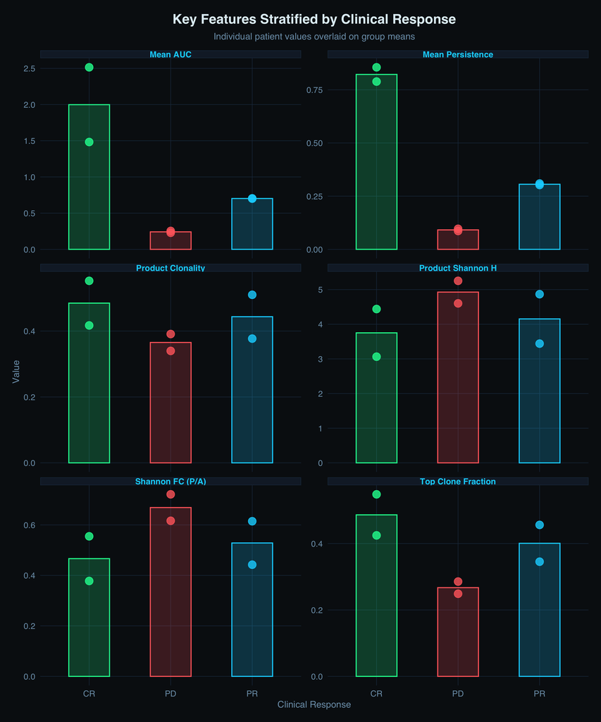

```r
# Reshape for faceted plotting
plot_features <- feature_matrix %>%
  select(patient_id, clinical_response,
         `Product Shannon H`   = product_shannon,
         `Product Clonality`   = product_clonality,
         `Mean AUC`            = mean_auc,
         `Mean Persistence`    = mean_persistence,
         `Top Clone Fraction`  = top1_fraction,
         `Shannon FC (P/A)`    = shannon_fc) %>%
  pivot_longer(-c(patient_id, clinical_response),
               names_to = "metric", values_to = "value")

ggplot(plot_features, aes(x = clinical_response, y = value,
                           fill = clinical_response, color = clinical_response)) +
  geom_col(data = . %>% group_by(clinical_response, metric) %>%
             summarise(value = mean(value), .groups = "drop"),
           alpha = 0.2, width = 0.5) +
  geom_point(size = 4, alpha = 0.8) +
  scale_fill_manual(values = c("CR" = "#00ff9d", "PR" = "#00d4ff", "PD" = "#ff6b6b")) +
  scale_color_manual(values = c("CR" = "#00ff9d", "PR" = "#00d4ff", "PD" = "#ff6b6b")) +
  facet_wrap(~ metric, scales = "free_y", ncol = 2) +
  labs(
    x = "Clinical Response", y = "Value",
    title = "Key Features Stratified by Clinical Response",
    subtitle = "Individual patient values overlaid on group means"
  ) +
  theme(
    legend.position = "none",
    strip.background = element_rect(fill = "#152231", color = "#1e3348"),
    strip.text = element_text(color = "#00d4ff", face = "bold", size = 10)
  )
```

## Composite Score

We construct a simple **composite score** that summarizes the key features associated with clinical response. Features are z-score normalized and combined with direction-aware weighting (higher clonality, AUC, and persistence are favorable; higher Shannon entropy in Product is unfavorable).

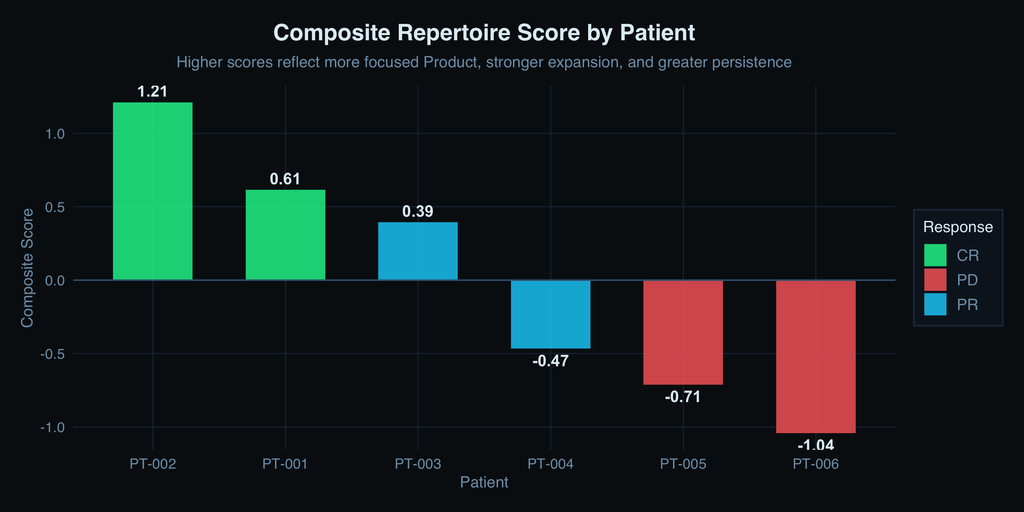

```r
# Z-score normalization
scored <- feature_matrix %>%
  mutate(
    z_clonality   = scale(product_clonality)[,1],
    z_auc         = scale(mean_auc)[,1],
    z_persistence = scale(mean_persistence)[,1],
    z_top1        = scale(top1_fraction)[,1],
    z_shannon_inv = -scale(product_shannon)[,1],  # invert: lower diversity = higher score

    # Composite: equal weight
    composite_score = (z_clonality + z_auc + z_persistence + z_top1 + z_shannon_inv) / 5
  )

ggplot(scored, aes(x = reorder(patient_id, -composite_score), y = composite_score,
                    fill = clinical_response)) +
  geom_col(alpha = 0.8, width = 0.6) +
  geom_text(aes(label = round(composite_score, 2)),
            vjust = ifelse(scored$composite_score > 0, -0.5, 1.5),
            color = "#e0eef5", size = 4, fontface = "bold") +
  scale_fill_manual(values = c("CR" = "#00ff9d", "PR" = "#00d4ff", "PD" = "#ff6b6b")) +
  geom_hline(yintercept = 0, color = "#3f6380", linewidth = 0.5) +
  labs(
    x = "Patient", y = "Composite Score",
    fill = "Response",
    title = "Composite Repertoire Score by Patient",
    subtitle = "Higher scores reflect more focused Product, stronger expansion, and greater persistence"
  )
```

> **Interpretation:** The composite score separates patients by clinical response, with CR patients scoring highest (most focused Product, strongest expansion, best persistence) and PD patients scoring lowest.

## Radar / Spider Plot — Patient Profiles

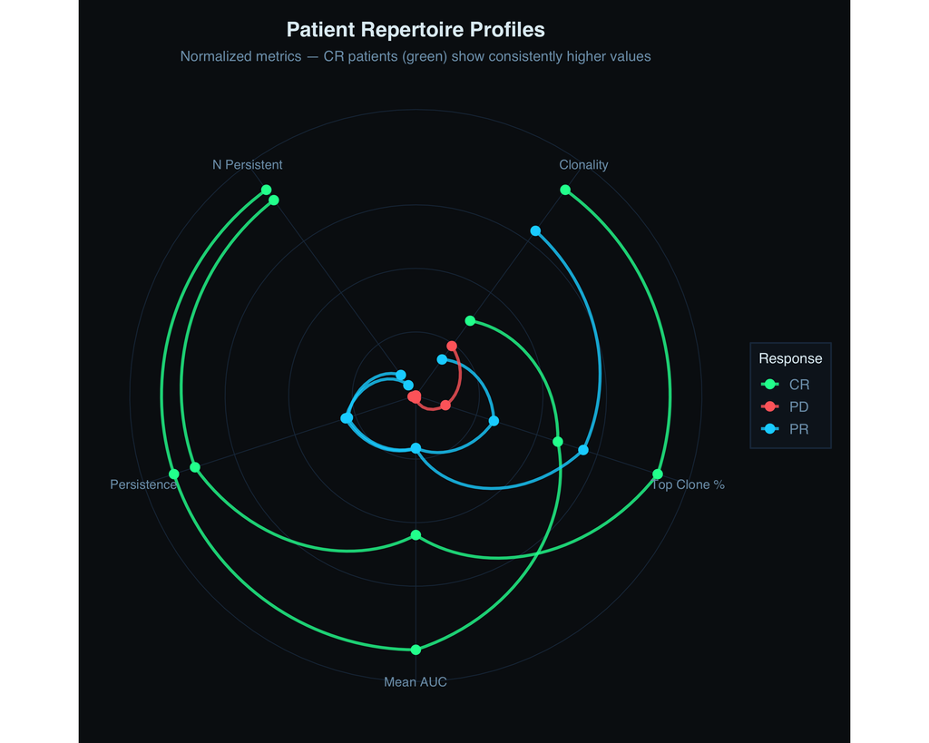

```r
# Normalize each feature to 0-1 range for radar visualization
radar_data <- scored %>%
  select(patient_id, clinical_response,
         Clonality = product_clonality,
         `Top Clone %` = top1_fraction,
         `Mean AUC` = mean_auc,
         Persistence = mean_persistence,
         `N Persistent` = n_persistent) %>%
  mutate(across(Clonality:`N Persistent`, ~ (. - min(.)) / (max(.) - min(.) + 1e-10)))

# Reshape for parallel coordinate plot (approximation of radar)
radar_long <- radar_data %>%
  pivot_longer(-c(patient_id, clinical_response),
               names_to = "metric", values_to = "value") %>%
  mutate(metric = factor(metric, levels = c("Clonality", "Top Clone %", "Mean AUC",
                                             "Persistence", "N Persistent")))

ggplot(radar_long, aes(x = metric, y = value, group = patient_id,
                        color = clinical_response)) +
  geom_line(linewidth = 1.1, alpha = 0.8) +
  geom_point(size = 3) +
  scale_color_manual(values = c("CR" = "#00ff9d", "PR" = "#00d4ff", "PD" = "#ff6b6b")) +
  coord_polar() +
  labs(
    title = "Patient Repertoire Profiles",
    subtitle = "Normalized metrics — CR patients (green) show consistently higher values",
    color = "Response"
  ) +
  theme(
    axis.text.y  = element_blank(),
    axis.title   = element_blank(),
    panel.grid.major = element_line(color = "#1e3348", linewidth = 0.3)
  )
```

## Statistical Testing — Response Group Comparisons

```r
# Kruskal-Wallis tests across response groups for key features
test_features <- c("product_shannon", "product_clonality", "mean_auc",
                    "mean_persistence", "top1_fraction")

kw_results <- map_dfr(test_features, function(feat) {
  formula <- as.formula(paste(feat, "~ clinical_response"))
  test <- kruskal.test(formula, data = feature_matrix)
  tibble(
    feature   = feat,
    statistic = round(test$statistic, 3),
    p_value   = round(test$p.value, 4),
    significant = test$p.value < 0.05
  )
})

kw_results %>%
  knitr::kable(caption = "Kruskal-Wallis tests: feature ~ clinical response")
```

Kruskal-Wallis tests: feature ~ clinical response

| feature | statistic | p_value | significant |
| --- | --- | --- | --- |
| product_shannon | 2.571 | 0.2765 | FALSE |
| product_clonality | 2.571 | 0.2765 | FALSE |
| mean_auc | 4.571 | 0.1017 | FALSE |
| mean_persistence | 4.571 | 0.1017 | FALSE |
| top1_fraction | 3.714 | 0.1561 | FALSE |

> **Note:** With n=2 per group, statistical power is extremely limited and p-values should be interpreted as descriptive trends rather than confirmatory evidence. In a real clinical trial, these analyses would be powered with larger cohorts.

## Summary Heatmap — Patient × Feature

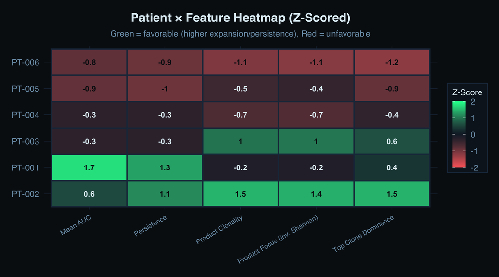

```r
# Z-scored heatmap of all key features
heatmap_data <- scored %>%
  select(patient_id, clinical_response,
         z_clonality, z_auc, z_persistence, z_top1, z_shannon_inv) %>%
  pivot_longer(-c(patient_id, clinical_response),
               names_to = "feature", values_to = "z_score") %>%
  mutate(feature = recode(feature,
    z_clonality   = "Product Clonality",
    z_auc         = "Mean AUC",
    z_persistence = "Persistence",
    z_top1        = "Top Clone Dominance",
    z_shannon_inv = "Product Focus (inv. Shannon)"
  ))

ggplot(heatmap_data, aes(x = feature, y = reorder(patient_id, -z_score), fill = z_score)) +
  geom_tile(color = "#1e3348", linewidth = 0.8) +
  geom_text(aes(label = round(z_score, 1)),
            color = ifelse(abs(heatmap_data$z_score) > 0.8, "#0a0f14", "#e0eef5"),
            size = 3.5, fontface = "bold") +
  scale_fill_gradient2(
    low = "#ff6b6b", mid = "#152231", high = "#00ff9d",
    midpoint = 0, limits = c(-2, 2)
  ) +
  labs(
    x = NULL, y = NULL, fill = "Z-Score",
    title = "Patient × Feature Heatmap (Z-Scored)",
    subtitle = "Green = favorable (higher expansion/persistence), Red = unfavorable"
  ) +
  theme(
    axis.text.x = element_text(angle = 30, hjust = 1, size = 9),
    axis.text.y = element_text(size = 11)
  )
```

## Conclusions

> **Integrated findings across the full TCR analysis pipeline:**
> 1. **Product repertoire focusing predicts response.** CR patients have the lowest Product Shannon entropy, highest clonality, and most dominant top clones — manufacturing efficiently selected a narrow set of therapeutic clonotypes.
> 2. **Post-infusion expansion kinetics separate responders from non-responders.** CR patients show stronger, later-peaking, and more persistent clonal expansion (higher AUC, higher persistence ratio).
> 3. **The composite score integrating diversity, expansion, and persistence separates clinical response groups**, suggesting that a multi-metric approach may be more informative than any single measure.
> 4. **These patterns are consistent across multiple analytical approaches** — descriptive diversity metrics (Notebook 02), clonal dominance analysis (Notebook 03), edgeR differential abundance (Notebook 04), longitudinal tracking (Notebook 05), and integrated feature analysis (this notebook) all converge on the same biological conclusion.

### Limitations & Future Directions

- **Sample size (n=6)** limits statistical power; larger cohorts needed for confirmatory analysis
- **Synthetic data** — patterns are designed to recapitulate known biology but are not derived from real patient samples
- **Predictive modeling** (logistic regression, random forest) would require larger cohorts to train and validate
- **Antigen specificity** analysis (e.g., linking expanded TCRs to known epitopes via databases like VDJdb or IEDB) would add biological interpretability
- **Multi-omic integration** (scRNA-seq, cytokine data, clinical labs) could further refine the response prediction model